# Kelompok 4_Praktikum_Pekan 9

Angga Fathan Rofiqy

24 April, 2024

> **Code/Syntax :** [File.rmd](https://github.com/Zen-Rofiqy/STA1372-MRS/blob/main/Project/Kelompok%204_Praktikum_Pekan%209.Rmd)

**Kelompok 4 Pararel 2**

| Nama | NIM |
| --- | --- |
| Angga Fathan Rofiqy | `G1401211006` |
| Gladys Adya Zafira | `G1401211014` |
| Kheni Hikmah Lestari | `G1401211029` |

# Latihan

1. Ulangi simulasi percobaan simpangan baku untuk n = 100 dan n = 500, bandingkan hasilnya!
2. Ulangi simulasi selang kepercayaan untuk n = 250, apa kesimpulannya?
3. Uangi simulasi penduga tak bias untuk sebaran eksponensial dan seragam, apakah s tetap tak bias?

## No 1

> Ulangi simulasi percobaan **simpangan baku** untuk **n = 100** dan **n = 500**, bandingkan hasilnya!

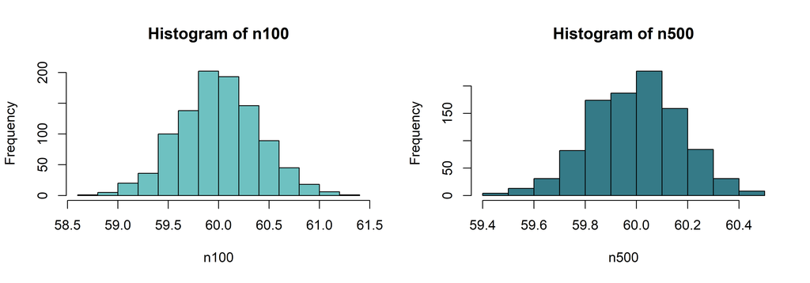

```r
set.seed(50)
n100 <- rep(NA, 1000)
for (i in 1:1000) {
  sample.40 <- rnorm(100, mean = 60, sd = 4)
  n100[i] <- mean(sample.40)
}
means100 <- mean(n100)
sd100 <- sd(n100)

n500 <- rep(NA, 1000)
for (i in 1:1000) {
  sample.500 <- rnorm(500, mean = 60, sd = 4)
  n500[i] <- mean(sample.500)
}
means500 <- mean(n500)
sd500 <- sd(n500)

par(mfrow = c(1, 2))
hist(n100, col = "#6ec1c1")
hist(n500, col = "#357a87")
```

```r
cat(" Untuk n = 100 :\n","mean = ", means100, "\n SD = ", sd100, "\n\n",
    "Untuk n = 500 :\n","mean = ", means500, "\n SD = ", sd500)
```

```
##  Untuk n = 100 :
##  mean =  60.0003
##  SD =  0.4013152
##
##  Untuk n = 500 :
##  mean =  59.99587
##  SD =  0.1758684
```

**Simpangan baku** yang **semakin kecil** menunjukkan bahwa distribusi sampel memiliki tingkat **variasi yang lebih rendah** atau lebih konsisten. Dalam konteks simulasi yang kami lakukan, ini mengindikasikan bahwa estimasi rata-rata populasi dari sampel-sampel yang diambil (baik untuk n = 100 maupun n = 500) menjadi semakin stabil atau **lebih dekat** dengan **nilai sebenarnya**, karena simpangan bakunya menurun.

Dengan kata lain, **semakin kecil simpangan bakunya**, **semakin akurat** estimasi rata-rata populasi dari sampel yang diambil. Ini menggambarkan keandalan atau kepercayaan yang lebih tinggi dalam penggunaan rata-rata sampel sebagai perkiraan rata-rata populasi. Jadi, semakin kecil simpangan bakunya, semakin baik estimasi yang kita miliki tentang rata-rata populasi sebenarnya.

## No 2

> Ulangi simulasi **selang kepercayaan** untuk **n = 250**, apa kesimpulannya?

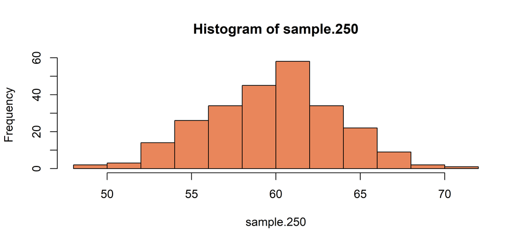

```r
set.seed(50)
sample.250 <- rnorm(250, mean = 60, sd = 4)
hist(sample.250, col = "#e9865b")
```

```r
(estimated.mean <- mean(sample.250))
```

```
## [1] 59.72593
```

```r
popSD <- 4
sample.size <- length(sample.250)
(sigma.mu <- popSD/sqrt(sample.size))
```

```
## [1] 0.2529822
```

$\bar x \pm (2 \times \sigma_\bar x) = 59.72593 \pm (2 \times 0.2529822)$

Ini menunjukkan bahwa dengan **meningkatnya ukuran sampel**, interval kepercayaan **cenderung menyempit**, atau dengan kata lain, kita menjadi **lebih yakin** tentang perkiraan **rata-rata populasi**.

Dengan kata lain, **semakin besar** ukuran sampel, **semakin akurat** perkiraan rata-rata populasi kita, yang tercermin dalam interval kepercayaan **yang lebih sempit**. Oleh karena itu, dengan meningkatnya ukuran sampel, tingkat kepercayaan kita terhadap estimasi rata-rata populasi meningkat.

## No 3

> Ulangi simulasi **penduga tak bias** untuk sebaran **eksponensial** dan **seragam**, apakah **s tetap tak bias**?

### Exp

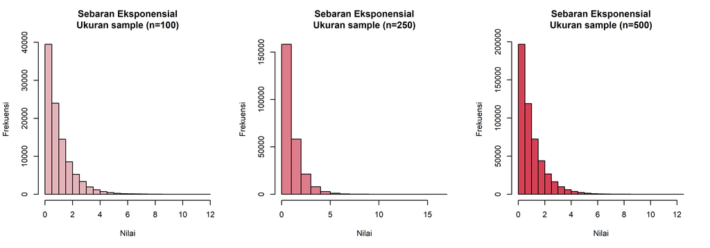

```r
set.seed(50)
k <- 1000 # ulangan (gak ada ketentuan berapa nya, alias bebas berapa aja)
sample_size <- c(100, 250, 500)

exp_samples <- lapply(sample_size, function(n) matrix(rexp(n*k, 1),k))

par(mfrow = c(1, 3))
hist(exp_samples[[1]], main = "Sebaran Eksponensial\nUkuran sample (n=100)",
     xlab = "Nilai", ylab = "Frekuensi", col = "#E4B3BA")
hist(exp_samples[[2]], main = "Sebaran Eksponensial\nUkuran sample (n=250)",
     xlab = "Nilai", ylab = "Frekuensi", col = "#DE7C8A")
hist(exp_samples[[3]], main = "Sebaran Eksponensial\nUkuran sample (n=500)",
     xlab = "Nilai", ylab = "Frekuensi", col = "#D44155")
```

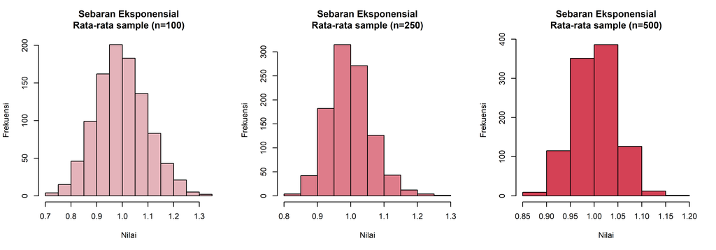

```r
dist_mean <- function(n, dist_samples){
  dist_means <- list()
  for (i in seq_along(n))
    dist_means[[i]] <- apply(dist_samples[[i]], 1, mean)
  return(dist_means)
}

exp_means <- dist_mean(sample_size, exp_samples)

par(mfrow = c(1, 3))
hist(exp_means[[1]], main = "Sebaran Eksponensial\nRata-rata sample (n=100)",
     xlab = "Nilai", ylab = "Frekuensi", col = "#E4B3BA")
hist(exp_means[[2]], main = "Sebaran Eksponensial\nRata-rata sample (n=250)",
     xlab = "Nilai", ylab = "Frekuensi", col = "#DE7C8A")
hist(exp_means[[3]], main = "Sebaran Eksponensial\nRata-rata sample (n=500)",
     xlab = "Nilai", ylab = "Frekuensi", col = "#D44155")
```

```r
cat(" Untuk n = ", sample_size[1], " :\n","mean = ", mean(exp_means[[1]]),
    "\n SD = ", sd(exp_means[[1]]), "\n\n",

    "Untuk n = ", sample_size[2], " :\n","mean = ", mean(exp_means[[2]]),
    "\n SD = ", sd(exp_means[[2]]), "\n\n",

    "Untuk n = ", sample_size[3], " :\n","mean = ", mean(exp_means[[3]]),
    "\n SD = ", sd(exp_means[[3]]) )
```

```
##  Untuk n =  100  :
##  mean =  0.9972514
##  SD =  0.1002608
##
##  Untuk n =  250  :
##  mean =  0.9978818
##  SD =  0.06275288
##
##  Untuk n =  500  :
##  mean =  1.002344
##  SD =  0.04427134
```

### Unif

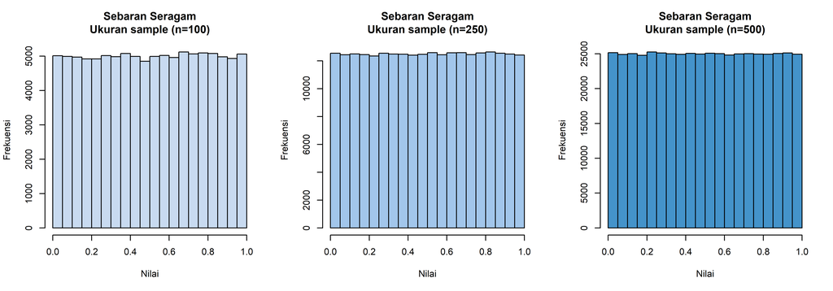

```r
set.seed(50)
k <- 1000 # ulangan (gak ada ketentuan berapa nya, alias bebas berapa aja)
sample_size <- c(100, 250, 500)

unif_samples <- lapply(sample_size, function(n) matrix(runif(n*k),k))

par(mfrow = c(1, 3))
hist(unif_samples[[1]], main = "Sebaran Seragam\nUkuran sample (n=100)",
     xlab = "Nilai", ylab = "Frekuensi", col = "#c8daf0")
hist(unif_samples[[2]], main = "Sebaran Seragam\nUkuran sample (n=250)",
     xlab = "Nilai", ylab = "Frekuensi", col = "#a2c6eb")
hist(unif_samples[[3]], main = "Sebaran Seragam\nUkuran sample (n=500)",
     xlab = "Nilai", ylab = "Frekuensi", col = "#4493CA")
```

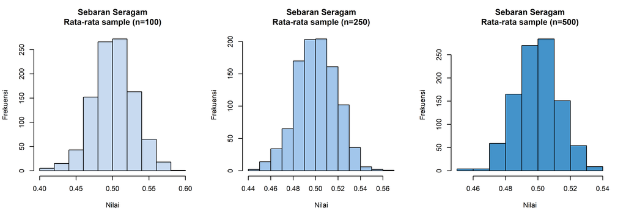

```r
unif_means <- dist_mean(sample_size, unif_samples)

par(mfrow = c(1, 3))
hist(unif_means[[1]], main = "Sebaran Seragam\nRata-rata sample (n=100)",
     xlab = "Nilai", ylab = "Frekuensi", col = "#c8daf0")
hist(unif_means[[2]], main = "Sebaran Seragam\nRata-rata sample (n=250)",
     xlab = "Nilai", ylab = "Frekuensi", col = "#a2c6eb")
hist(unif_means[[3]], main = "Sebaran Seragam\nRata-rata sample (n=500)",
     xlab = "Nilai", ylab = "Frekuensi", col = "#4493CA")
```

```r
cat(" Untuk n = ", sample_size[1], " :\n","mean = ", mean(unif_means[[1]]),
    "\n SD = ", sd(unif_means[[1]]), "\n\n",

    "Untuk n = ", sample_size[2], " :\n","mean = ", mean(unif_means[[2]]),
    "\n SD = ", sd(unif_means[[2]]), "\n\n",

    "Untuk n = ", sample_size[3], " :\n","mean = ", mean(unif_means[[3]]),
    "\n SD = ", sd(unif_means[[3]]) )
```

```
##  Untuk n =  100  :
##  mean =  0.5012812
##  SD =  0.02802082
##
##  Untuk n =  250  :
##  mean =  0.5004866
##  SD =  0.01805046
##
##  Untuk n =  500  :
##  mean =  0.4998646
##  SD =  0.01304787
```